# QTM 385 Homework 1

Chelsey Kim, Ayah Noor Assaadi

9/30/2021

##### Set-Up

```r
library(MASS)
library(class)
library(boot)
library(ISLR2)
```

#### Problem 1: For each of parts (a) through (c), indicate whether we would generally expect the performance of a flexible statistical learning method to be better or worse than an inflexible method. Justify your answer.

##### (a) The sample size n is extremely large, and the number of predictors p is small.

The flexible statistical learning method would perform better than the inflexible method when the sample size n is large and the predictors is small. Because the sample size is extremely large, the flexible method would be able to fit the data closer and find more complex relationships without overfitting.

##### (b) The number of predictors p is extremely large, and the number of observations n is small.

The flexible statistical learning method would preform worse than the inflexible model when the number of predictors is large and the sample size is small. Because there are high dimensions due to the large number of predictors, and a small number of observations, a flexible method may overfit the data. In other words, there is a larger risk that the data will find false relationships.

##### (c) The relationship between the predictors and response is highly non-linear.

The flexible statsitical learning method would preform better when the relationship between the predictors and response is highly non-linear. This is because the flexible model will be able to capture the non-linear relationship between the predictor and response.

#### Problem 2: We now revisit the bias-variance decomposition.

##### (a) Provide a sketch of typical (squared) bias, variance, training error, test error, and irreducible error curves, on a single plot, as we go from less flexible statistical learning methods towards more flexible approaches. The x-axis should represent the amount of flexibility in the method, and the y-axis should represent the values for each curve. There should be five curves. Make sure to label each one.

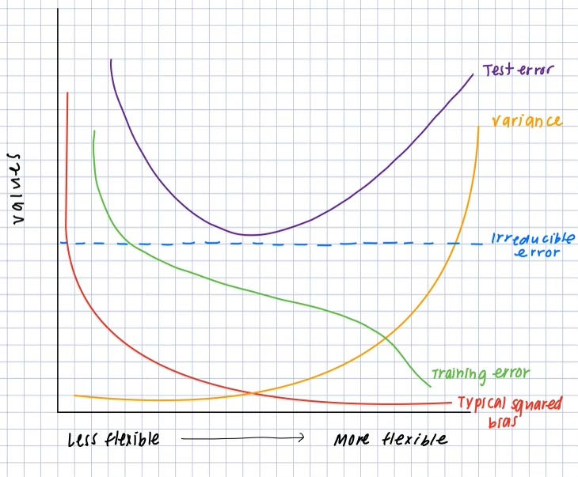

##### (b) Explain why each of the five curves has the shape displayed in part (a)

The squared bias curve decreases as the model becomes more flexible because increases in flexibility yield a closer fit.

The training error curve also decreases as flexibility increases. Increases in flexibility yield a closer fit.

The irreducible error is a constant horizontal dashed line that indicates the Var(ε), which corresponds to the lowest achievable test MSE among all the possible methods.

The variance curve increases as flexibility increases because increases in flexibility yield an over fit.

#### Problem 3: Suppose we have a data set with five predictors, X1 = GPA, X2 = IQ, X3 = Level (1 for College and 0 for High School), X4 = Interaction between GPA and IQ, and X5 = Interaction between GPA and Level. The response is starting salary after graduation (in thousands of dollars). Suppose we use least squares to fit the model, and get βˆ0 = 50, βˆ1 = 20, βˆ2 = 0.05, βˆ3 = 40, βˆ4 = 0.02, βˆ5 = −15.

##### (a) Which answer is correct, and why?

###### (iii) For a fixed value of IQ and GPA, high school graduates earn more, on average, than college graduates provided that the GPA is high enough.

The least square line is: $50 + 20 GPA + 0.05 IQ + 40 Level + 0.02 GPA x IQ - 15 GPA x Level$

For those that have high school level education, the least square line is: $50 + 20GPA + 0.05IQ + 0.02GPA*IQ$

For those that have college level education, the least square line is: $90 + 5GPA + 0.05IQ + 0.02GPA*IQ$

The starting salary for highschoolers is higher than for college students on average $50 + 20GPA \geq 90 + 5GPA$ if the GPA is greater than $2.\overline{66}$. Therefore, iii is correct.

##### (b) Predict the salary of a college graduate with IQ of 120 and a GPA of 4.0

Again, the least square line estimate for those with a college level of education is $90 + 5GPA + 0.05IQ + 0.02GPA*IQ$.

```r
90 + (5*4.0) + (0.05 * 120) + (0.2*120*4.0)
```

[output not shown]

##### (c) True or false: Since the coefficient for the GPA/IQ interaction term is very small, there is very little evidence of an interaction effect. Justify your answer.

**False.** The coefficient for the GPA/IQ interaction term does not determine whether or not there is an interaction effect, rather we need to determine the p-value of the tested hypothesis $H_0:\hat{B_4} = 0$. The p-value determines evidence for statistical significance, not the magnitude of the coefficient.

#### Problem 4: This question should be answered using the Carseats data set. This data set has the information about car seat sales in 400 stores and is part of the ISLR2 library. You can find the description of this data set at https://rdrr.io/cran/ISLR/man/Carseats.html.

```r
df1 <- Carseats
```

##### (a) Fit a multiple regression model to predict Sales using Price, Advertising, Urban, and US. (Hint: You may find lm() helpful)

```r
linear_model <- lm(Sales ~ Price + Advertising + Urban + US, data = df1)
summary(linear_model)
```

```
##
## Call:
## lm(formula = Sales ~ Price + Advertising + Urban + US, data = df1)
##
## Residuals:
##    Min     1Q Median     3Q    Max
## -7.879 -1.565 -0.027  1.543  6.367
##
## Coefficients:
##              Estimate Std. Error t value Pr(>|t|)
## (Intercept) 13.011278   0.633326  20.544  < 2e-16 ***
## Price       -0.054612   0.005099 -10.710  < 2e-16 ***
## Advertising  0.120333   0.024837   4.845 1.82e-06 ***
## UrbanYes    -0.038790   0.264279  -0.147    0.883
## USYes        0.058514   0.345060   0.170    0.865
## ---
## Signif. codes:  0 '***' 0.001 '**' 0.01 '*' 0.05 '.' 0.1 ' ' 1
##
## Residual standard error: 2.405 on 395 degrees of freedom
## Multiple R-squared:  0.2819, Adjusted R-squared:  0.2747
## F-statistic: 38.77 on 4 and 395 DF,  p-value: < 2.2e-16
```

##### (b) Provide an interpretation of each coefficient in the model. Be careful—some of the variables in the model are qualitative!

*Price* When the price increases by 1,000 dollars, the unit sale decreases by 54.61 dollars.

*Advertising* When the store increases their advertising budget by 1,000 dollars, the unit sale increases by 120.33 dollars.

*Urban* Urban areas have 38.79 (about 39) fewer car seats on average compared to non-urban areas.

*US* Stores in the United States have 58.514 (about 59) more car seat sales on average compared to non-US stores.

##### (c) Write out the model in equation form, being careful to handle the qualitative variables properly.

$\hat{Y} = 13.011 - 0.0546B_1 + 0.120B_2 - 0.0388B_3 + 0.0585B_4$

##### (d) For which of the predictors can you reject the null hypothesis H0 : βj = 0?

Price and Advertising have p-values that are less than 0.05. Therefore, there is strong evidence to reject the null hypothesis.

##### (e) On the basis of your response to the previous question, fit a smaller model that only uses the predictors for which there is evidence of association with the outcome.

```r
smaller_linear_model <- lm(Sales ~ Price + Advertising, data = df1)
summary(smaller_linear_model)
```

```
##
## Call:
## lm(formula = Sales ~ Price + Advertising, data = df1)
##
## Residuals:
##     Min      1Q  Median      3Q     Max
## -7.9011 -1.5470 -0.0223  1.5361  6.3748
##
## Coefficients:
##              Estimate Std. Error t value Pr(>|t|)
## (Intercept) 13.003427   0.606850  21.428  < 2e-16 ***
## Price       -0.054613   0.005078 -10.755  < 2e-16 ***
## Advertising  0.123107   0.018079   6.809 3.64e-11 ***
## ---
## Signif. codes:  0 '***' 0.001 '**' 0.01 '*' 0.05 '.' 0.1 ' ' 1
##
## Residual standard error: 2.399 on 397 degrees of freedom
## Multiple R-squared:  0.2819, Adjusted R-squared:  0.2782
## F-statistic: 77.91 on 2 and 397 DF,  p-value: < 2.2e-16
```

##### (f) How well do the models in (a) and (e) fit the data?

The residual standard error for the first linear regression in a is 2.405 on 395 degrees of freedom and the $R^2$ is 0.2819. The residual standard error for the smaller linear regression is 2.399 on 397 degrees of freedom and also has an $R^2$ of 0.2819. Therefore, both the linear regressions fit the data similarly. The slight smaller RSE for the smaller model indicates this linear regression fitting the data slightly better.

##### (g) Using the model from (e), obtain 95% confidence intervals for the coefficient(s).

```r
confint(smaller_linear_model)
```

```
##                   2.5 %      97.5 %
## (Intercept) 11.81038510 14.19646884
## Price       -0.06459643 -0.04462966
## Advertising  0.08756416  0.15864996
```

#### Problem 5 In this problem, you will develop a model to predict whether a given car gets high or low gas mileage based on the Auto data set. The Auto data set has gas mileage, horsepower, and other information for cars. You can find the description of this data set at https://rdrr.io/cran/ISLR/man/Auto.html

```r
df <- Auto
df <- df[!is.na(df$horsepower),]
```

##### (a) Create a binary variable, mpg01, that contains a 1 if mpg contains a value above its median, and a 0 if mpg contains a value below its median. (Hint: You could compute the median using the median() function. You could add the mpg01 column in df.)

```r
attach(df)
mpg01 = rep(0, length(mpg))
mpg01[mpg > median(mpg)] = 1
df = data.frame(df, mpg01)
```

##### (b) Explore the data graphically in order to investigate the association between mpg01 and the other features. Which of the other features seem most likely to be useful in predicting mpg01? Scatterplots and boxplots may be useful tools to answer this question. Describe your findings.(Hint: You may find pairs() helpful)

```r
cor(subset(df, select = -name))
```

```
##                     mpg  cylinders displacement horsepower     weight
## mpg           1.0000000 -0.7776175   -0.8051269 -0.7784268 -0.8322442
## cylinders    -0.7776175  1.0000000    0.9508233  0.8429834  0.8975273
## displacement -0.8051269  0.9508233    1.0000000  0.8972570  0.9329944
## horsepower   -0.7784268  0.8429834    0.8972570  1.0000000  0.8645377
## weight       -0.8322442  0.8975273    0.9329944  0.8645377  1.0000000
## acceleration  0.4233285 -0.5046834   -0.5438005 -0.6891955 -0.4168392
## year          0.5805410 -0.3456474   -0.3698552 -0.4163615 -0.3091199
## origin        0.5652088 -0.5689316   -0.6145351 -0.4551715 -0.5850054
## mpg01         0.8369392 -0.7591939   -0.7534766 -0.6670526 -0.7577566
##              acceleration       year     origin      mpg01
## mpg             0.4233285  0.5805410  0.5652088  0.8369392
## cylinders      -0.5046834 -0.3456474 -0.5689316 -0.7591939
## displacement   -0.5438005 -0.3698552 -0.6145351 -0.7534766
## horsepower     -0.6891955 -0.4163615 -0.4551715 -0.6670526
## weight         -0.4168392 -0.3091199 -0.5850054 -0.7577566
## acceleration    1.0000000  0.2903161  0.2127458  0.3468215
## year            0.2903161  1.0000000  0.1815277  0.4299042
## origin          0.2127458  0.1815277  1.0000000  0.5136984
## mpg01           0.3468215  0.4299042  0.5136984  1.0000000
```

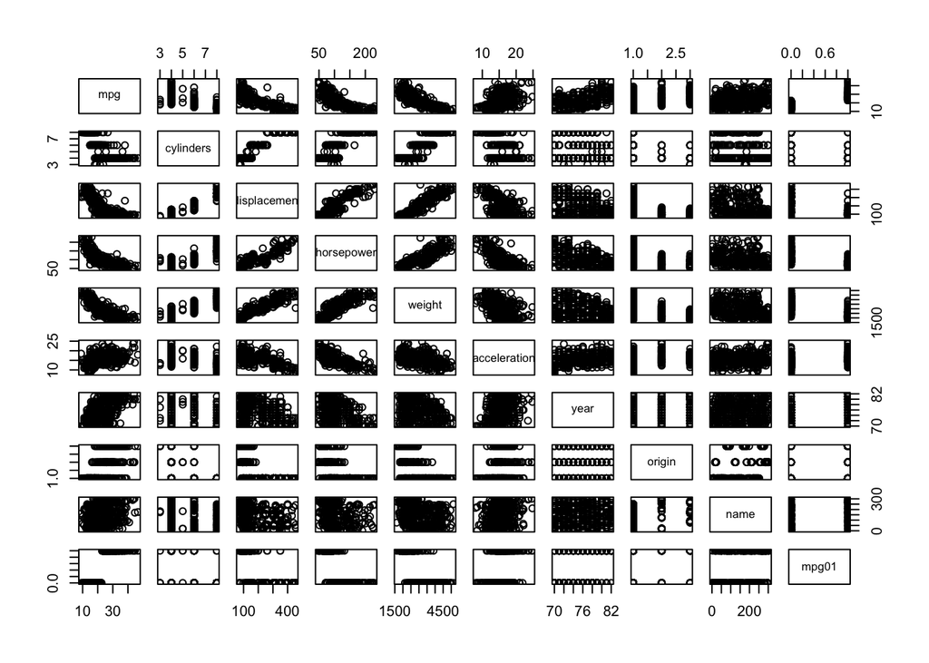

```r
pairs(df)
```

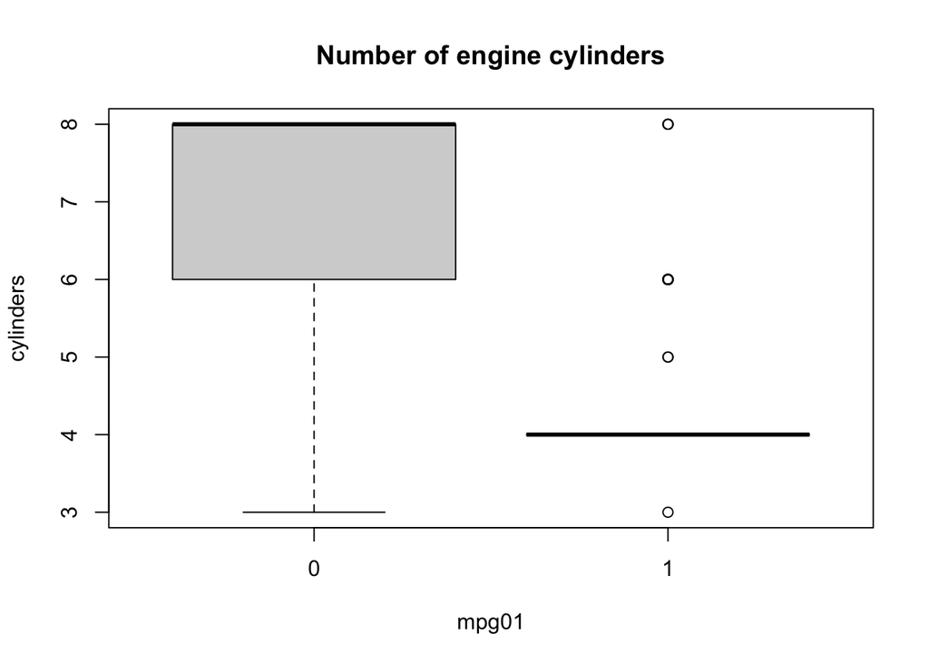

```r
boxplot(cylinders ~ mpg01, data = df, main = "Number of engine cylinders")
```

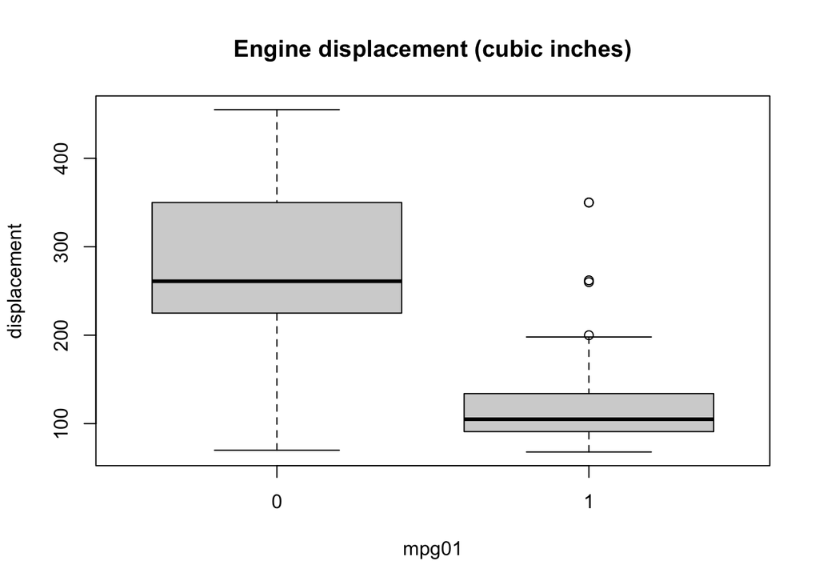

```r
boxplot(displacement ~ mpg01, data = df, main = "Engine displacement (cubic inches)")
```

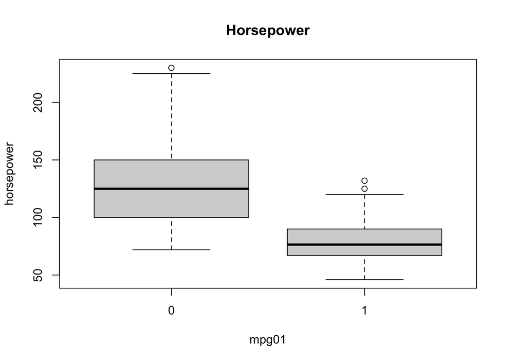

```r
boxplot(horsepower ~ mpg01, data = df, main = "Horsepower")
```

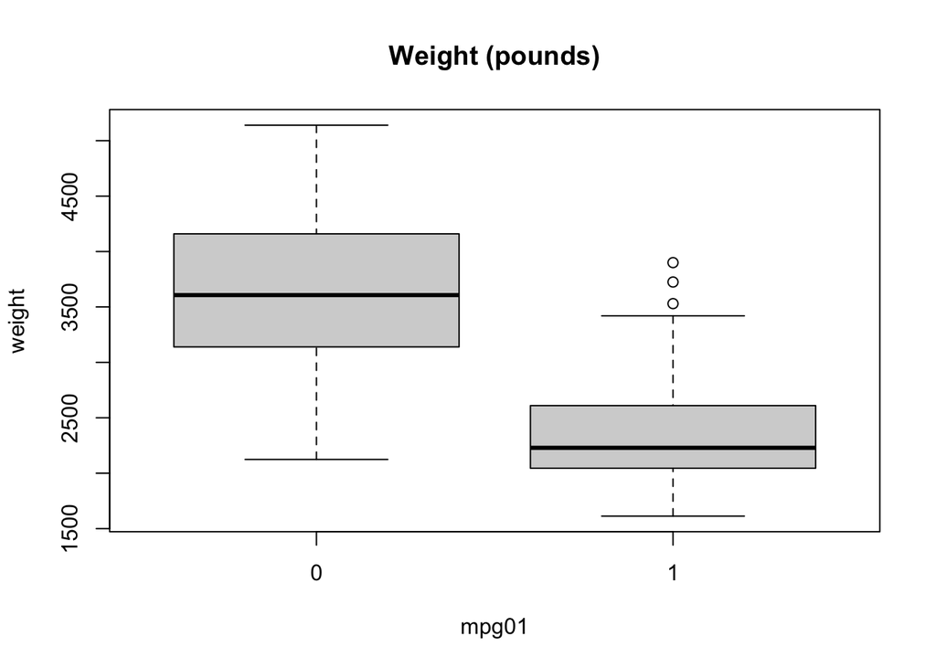

```r
boxplot(weight ~ mpg01, data = df, main = "Weight (pounds)")
```

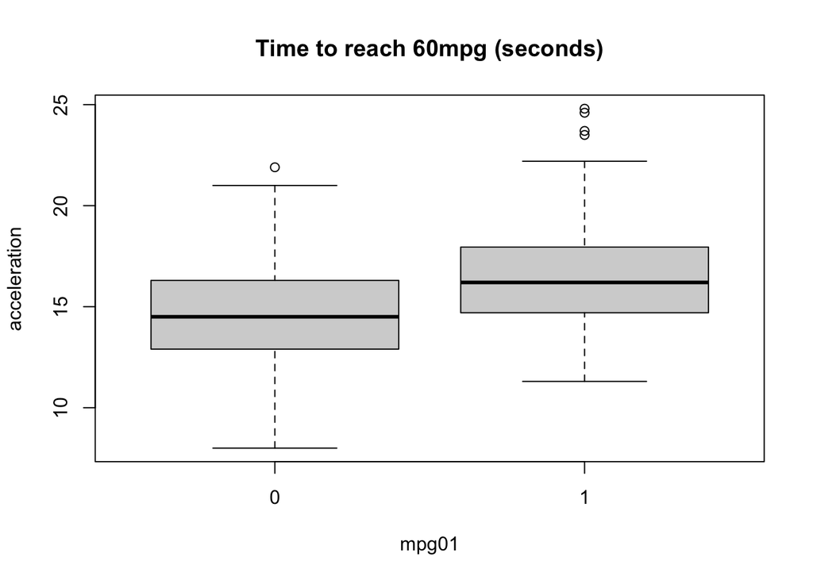

```r
boxplot(acceleration ~ mpg01, data = df, main = "Time to reach 60mpg (seconds)")
```

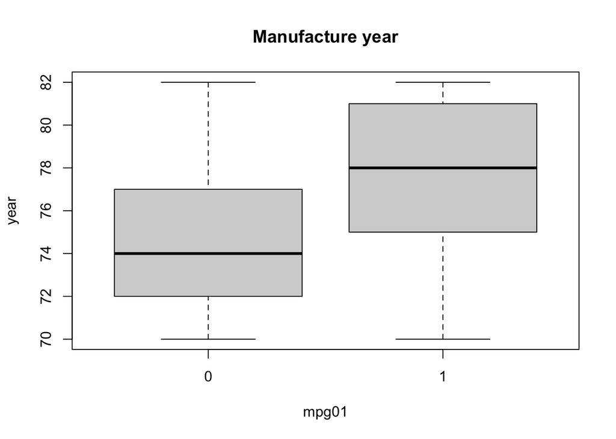

```r
boxplot(year ~ mpg01, data = df, main = "Manufacture year")
```

Cylinders, weight, displacement, horsepower (and mpg itself) seem most likely to be useful in predicting mpg01.

##### (c) Split the data into a training set and a test set with 80% observations in the training set and 20% observations in the test set. (Hint: You may find sample.split() in the caTools library helpful)

```r
train <- sample(nrow(df) * 0.8)
train_set <- df[train, ]
test_set <- df[-train, ]
```

##### (d) Perform logistic regression on the training data in order to predict mpg01 using cylinders, weight, displacement, and horsepower. What is the test error of the model obtained? (Hint: You may find glm(formula, data, family = binomial), predict(), and table() helpful)

```r
fmla <- as.formula('mpg01 ~ cylinders + weight + displacement + horsepower')
glm.fit <- glm(formula = fmla, data = df, subset = train, family = binomial)
summary(glm.fit)$coef
```

```
##                  Estimate   Std. Error    z value     Pr(>|z|)
## (Intercept)  12.515214659 2.1418871334  5.8430785 5.124485e-09
## cylinders    -0.088561926 0.4620535756 -0.1916703 8.480005e-01
## weight       -0.002254429 0.0008609119 -2.6186519 8.827797e-03
## displacement -0.010400370 0.0111064057 -0.9364299 3.490519e-01
## horsepower   -0.047423248 0.0176447459 -2.6876697 7.195254e-03
```

```r
glm.pred <- predict(glm.fit, test_set, type = 'response')
glm.pred_1 = rep(0, length(glm.pred))
glm.pred_1[glm.pred > .5] = 1
table(glm.pred_1, test_set$mpg01)
```

```
##
## glm.pred_1  0  1
##          0  5 13
##          1  0 61
```

```r
mean(glm.pred_1 != test_set$mpg01)
```

```
## [1] 0.164557
```

##### (e) Perform LDA on the training data in order to predict mpg01 using cylinders, weight, displacement, and horsepower. What is the test error of the model obtained? (Hint: You may find lda() in the MASS library helpful)

```r
fmla <- as.formula('mpg01 ~ cylinders + weight + displacement + horsepower')
lda.fit <- lda(fmla, data = df, subset = train)
lda.pred = predict(lda.fit,test_set)
lda.class = lda.pred$class
table(lda.class,test_set$mpg01)
```

```
##
## lda.class  0  1
##         0  5 11
##         1  0 63
```

```r
1 - mean(lda.pred$class == test_set$mpg01)
```

```
## [1] 0.1392405
```

The test error of the LDA model obtained is 0.1392405.

##### (f) Perform QDA on the training data in order to predict mpg01 using cylinders, weight, displacement, and horsepower. What is the test error of the model obtained? (Hint: You may find qda() in the MASS library helpful)

```r
qda.fit = qda(mpg01~cylinders+weight+displacement+horsepower+origin, data = df, subset = train)
qda.pred = predict(qda.fit,test_set)
qda.class = qda.pred$class
table(qda.class,test_set$mpg01)
```

```
##
## qda.class  0  1
##         0  5 10
##         1  0 64
```

```r
1 - mean(qda.pred$class == test_set$mpg01)
```

```
## [1] 0.1265823
```

The test error of the QDA model obtained is 0.1265823.

##### (g) Perform KNN on the training data, with several values of K, in order to predict mpg01 using cylinders, weight, displacement, and horsepower. What test errors do you obtain? Which value of K seems to perform the best on this data set? (Hint: You may find knn() in the class library helpful)

```r
train.X = cbind(cylinders, displacement, horsepower, weight)[train, ]
test.X = cbind(cylinders, displacement, horsepower, weight)[-train, ]
train.mpg01 = df[train, "mpg01"]
set.seed(1)
knn.pred = knn(train.X, test.X, train.mpg01, k = 1)
table(knn.pred, df[-train, "mpg01"])
```

```
##
## knn.pred  0  1
##        0  5 17
##        1  0 57
```

```r
mean(knn.pred != df[-train, "mpg01"])
```

```
## [1] 0.2151899
```

```r
knn.pred01 = knn(train.X, test.X, train.mpg01, k = 2)
table(knn.pred01, df[-train, "mpg01"])
```

```
##
## knn.pred01  0  1
##          0  5 18
##          1  0 56
```

```r
mean(knn.pred01 != df[-train, "mpg01"])
```

```
## [1] 0.2278481
```

```r
knn.pred02 = knn(train.X, test.X, train.mpg01, k = 3)
table(knn.pred02, df[-train, "mpg01"])
```

```
##
## knn.pred02  0  1
##          0  5 20
##          1  0 54
```

```r
mean(knn.pred02 != df[-train, "mpg01"])
```

```
## [1] 0.2531646
```

```r
knn.pred03 = knn(train.X, test.X, train.mpg01, k = 4)
table(knn.pred03, df[-train, "mpg01"])
```

```
##
## knn.pred03  0  1
##          0  5 20
##          1  0 54
```

```r
mean(knn.pred03 != df[-train, "mpg01"])
```

```
## [1] 0.2531646
```

```r
knn.pred04 = knn(train.X, test.X, train.mpg01, k = 10)
table(knn.pred04, df[-train, "mpg01"])
```

```
##
## knn.pred04  0  1
##          0  5 18
##          1  0 56
```

```r
mean(knn.pred04 != df[-train, "mpg01"])
```

```
## [1] 0.2278481
```

```r
knn.pred05 = knn(train.X, test.X, train.mpg01, k = 100)
table(knn.pred05, df[-train, "mpg01"])
```

```
##
## knn.pred05  0  1
##          0  5 17
##          1  0 57
```

```r
mean(knn.pred05 != df[-train, "mpg01"])
```

```
## [1] 0.2151899
```

Here we see that 𝑘=1 and k=100 have the lowest test error, with a value of 0.2151899

#### Problem 6 We will now perform cross-validation on a simulated data set.

##### (a) In this data set, what is n and what is p? Write out the model used to generate the data in equation form.

```r
set.seed(12345)
     x <- rnorm(200)
     y <- x + 2 * x**2 - 2 * x**3 + rnorm(200)
```

n = 200, p = 3 The model used is y = x + 2x^2 - 2x^3 + error.

##### (b) Create a scatterplot of X against Y . Comment on what you find. (Hint: You may find plot() helpful)

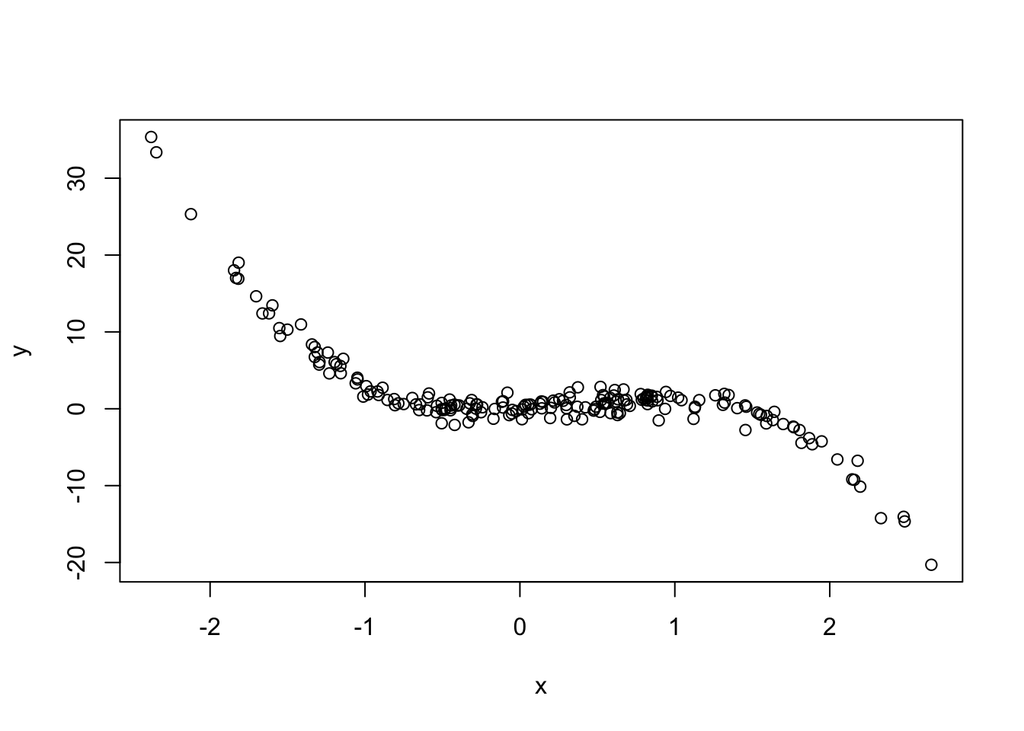

```r
plot(x,y)
```

##### (c) Set a random seed 123, and then compute the LOOCV errors that result from fitting the following five models using least squares:

##### (i) Y = β0 + β1X + ε

##### (ii) Y =β0 +β1X+β2X2 +ε

##### ((iii) Y =β0 +β1X+β2X2 +β3X3 +ε

##### ((iv) Y =β0 +β1X+β2X2 +β3X3 +β4X4 +ε

##### ((v) Y =β0 +β1X+β2X2 +β3X3 +β4X4 +β5X5 +ε (Hint: You may find cv.glm() in the boot library helpful)

```r
set.seed(123)
Data <- data.frame(x, y)
fit.glm.1 <- glm(y ~ x)
cv.glm(Data, fit.glm.1)$delta[1]
```

```
## [1] 17.36807
```

```r
fit.glm.2 <- glm(y ~ poly(x, 2))
cv.glm(Data, fit.glm.2)$delta[1]
```

```
## [1] 16.04318
```

```r
fit.glm.3 <- glm(y ~ poly(x, 3))
cv.glm(Data, fit.glm.3)$delta[1]
```

```
## [1] 0.9502418
```

```r
fit.glm.4 <- glm(y ~ poly(x, 4))
cv.glm(Data, fit.glm.4)$delta[1]
```

```
## [1] 0.9426056
```

```r
fit.glm.5 <- glm(y ~ poly(x, 5))
cv.glm(Data, fit.glm.5)$delta[1]
```

```
## [1] 0.9290121
```

##### (d) Repeat (c) using another random seed 12345, and report your results. Are your results the same as what you got in (c)? Why?

```r
set.seed(12345)
Data <- data.frame(x, y)
fit.glm.1 <- glm(y ~ x)
cv.glm(Data, fit.glm.1)$delta[1]
```

```
## [1] 17.36807
```

```r
fit.glm.2 <- glm(y ~ poly(x, 2))
cv.glm(Data, fit.glm.2)$delta[1]
```

```
## [1] 16.04318
```

```r
fit.glm.3 <- glm(y ~ poly(x, 3))
cv.glm(Data, fit.glm.3)$delta[1]
```

```
## [1] 0.9502418
```

```r
fit.glm.4 <- glm(y ~ poly(x, 4))
cv.glm(Data, fit.glm.4)$delta[1]
```

```
## [1] 0.9426056
```

```r
fit.glm.5 <- glm(y ~ poly(x, 5))
cv.glm(Data, fit.glm.5)$delta[1]
```

```
## [1] 0.9290121
```

The results we got for question (d) are the same as the results we got in (c). This is because LOOCV evaluates n folds of a single observation.

##### (e) Which of the models in (c) had the smallest LOOCV error? Is this what you expected? Explain your answer.

The LOOCV estimate for the test MSE is the smallest for “fit.glm.5”. This is not expected, for the relation between “x” and “y” is cubic and not 5th degree polynomial.

##### (f) Comment on the statistical significance of the coefficient estimates that results from fitting each of the models in (c) using least squares. Do these results agree with the conclusions drawn based on the cross-validation results?

```r
summary(fit.glm.5)
```

```
##
## Call:
## glm(formula = y ~ poly(x, 5))
##
## Deviance Residuals:
##      Min        1Q    Median        3Q       Max
## -2.75662  -0.55667   0.04405   0.57227   2.34191
##
## Coefficients:
##              Estimate Std. Error t value Pr(>|t|)
## (Intercept)   1.49871    0.06718  22.308   <2e-16 ***
## poly(x, 5)1 -62.49002    0.95010 -65.772   <2e-16 ***
## poly(x, 5)2  21.21992    0.95010  22.334   <2e-16 ***
## poly(x, 5)3 -51.98209    0.95010 -54.712   <2e-16 ***
## poly(x, 5)4  -1.62813    0.95010  -1.714   0.0882 .
## poly(x, 5)5   1.81275    0.95010   1.908   0.0579 .
## ---
## Signif. codes:  0 '***' 0.001 '**' 0.01 '*' 0.05 '.' 0.1 ' ' 1
##
## (Dispersion parameter for gaussian family taken to be 0.9026981)
##
##     Null deviance: 7238.49  on 199  degrees of freedom
## Residual deviance:  175.12  on 194  degrees of freedom
## AIC: 555.01
##
## Number of Fisher Scoring iterations: 2
```

The p-values indicate that the linear, quadratic and cubic terms are statistically significant and that the 4th and 5th degree terms are not statistically significant. This does not agree with our cross-validation results which were minimum for the 4th and 5th polynomial model.